# R Notebook

Ryan Willett

```r
library(ggplot2)
library(tidyverse)
library(feather)
```

```r
country_labels <- read.csv("additional_data/countries_labels.csv")

all_countries_agg <- read_feather("parsed_data/all_countries_summary.feather")
```

```
Coercing int64 to doubleCoercing int64 to double
```

```r
all_countries_seg <- read_feather("parsed_data/regional_confirmed.feather")
```

```
Coercing int64 to double
```

```r
all_countries_seg_deaths <- read_feather("parsed_data/regional_deaths.feather")
```

```
Coercing int64 to double
```

```r
rolling_cases <- read_feather("parsed_data/rolling_cases_country.feather")
rolling_deaths <- read_feather("parsed_data/rolling_deaths_country.feather")

rolling_cases_states <- read_feather("parsed_data/states_cases_rolling.feather")
rolling_deaths_states <- read_feather("parsed_data/states_deaths_rolling.feather")
```

```r
country_labels %>% head()
```

|  | Countries | Region | Longitude | Latitude | Subregion |
| --- | --- | --- | --- | --- | --- |
| 1 | Thailand | Asia | 15.87 | 100.9925 | Southeast Asia |
| 2 | Japan | Asia | 36.20 | 138.2529 | East Asia |
| 3 | Singapore | Asia | 1.35 | 103.8198 | East Asia |
| 4 | Nepal | Asia | 28.39 | 84.1240 | South Asia |
| 5 | Malaysia | Asia | 4.21 | 101.9758 | Southeast Asia |
| 6 | Canada | North America | 56.13 | -106.3468 | North America |

```r
rolling_cases %>% head()
```

| Date | new_confirmed100k | Country | Region |
| --- | --- | --- | --- |
| 2020-01-22 19:00:00 | 0 | Afghanistan | Asia |
| 2020-01-23 19:00:00 | 0 | Afghanistan | Asia |
| 2020-01-24 19:00:00 | 0 | Afghanistan | Asia |
| 2020-01-25 19:00:00 | 0 | Afghanistan | Asia |
| 2020-01-26 19:00:00 | 0 | Afghanistan | Asia |
| 2020-01-27 19:00:00 | 0 | Afghanistan | Asia |

Merge the Subregion onto the country

```r
rolling_cases_srg = merge(rolling_cases, country_labels, by.x = c('Country', 'Region'), by.y = c('Countries', 'Region'))
rolling_deaths_srg = merge(rolling_deaths, country_labels, by.x = c('Country', 'Region'), by.y = c('Countries', 'Region'))
```

Subsetting by General Region

```r
#NEW CASES
asia_newcases <- rolling_cases %>% filter(Region=='Asia' | Region=="Middle East")
europe_newcases <- rolling_cases %>% filter(Region=='Europe')
west_newcases <- rolling_cases %>% filter(Region=='North America' | Region=="South America")

#NEW DEATHS
asia_newdeaths <- rolling_deaths %>% filter(Region=='Asia' | Region=="Middle East")
europe_newdeaths <- rolling_deaths %>% filter(Region=='Europe')
west_newdeaths <- rolling_deaths %>% filter(Region=='North America' | Region=="South America")
```

```r
sw_states <- c("Arizona", "New Mexico", "Nevada", "Utah")
carolinas <- c("North Carolina", "South Carolina")
```

```r
sw_data <- rolling_cases_states %>% filter(state %in% sw_states)
carolinas_data <- rolling_cases_states %>% filter(state %in% carolinas)
```

```r
sw_data2 <- sw_data %>% filter(date > as.POSIXct("2020-03-01", "%Y-%m-%d"))
```

[output not shown]

```r
sw_data2
```

| date | new_cases_pop100k | abbrev | state |
| --- | --- | --- | --- |
| 2020-03-01 19:00:00 | 0.000000000 | AZ | Arizona |
| 2020-03-02 19:00:00 | 0.001962669 | AZ | Arizona |
| 2020-03-03 19:00:00 | 0.001962669 | AZ | Arizona |
| 2020-03-04 19:00:00 | 0.001962669 | AZ | Arizona |
| 2020-03-05 19:00:00 | 0.003925339 | AZ | Arizona |
| 2020-03-06 19:00:00 | 0.007850677 | AZ | Arizona |
| 2020-03-07 19:00:00 | 0.007850677 | AZ | Arizona |
| 2020-03-08 20:00:00 | 0.009813346 | AZ | Arizona |
| 2020-03-09 20:00:00 | 0.007850677 | AZ | Arizona |
| 2020-03-10 20:00:00 | 0.013738685 | AZ | Arizona |

[output cut: 448 more lines]

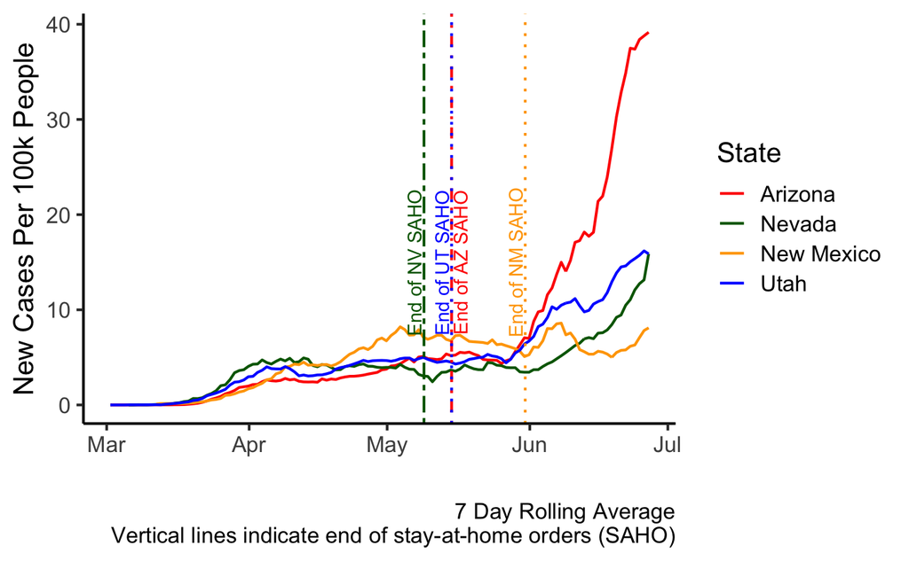

```r
man_col <- scale_color_manual(values = c("red", "darkgreen", "orange", "blue"))

ggplot(sw_data2, aes(x=date, y=new_cases_pop100k, col=state)) +
  geom_line(size=0.75) +
  theme_classic(base_size = 16) + man_col +
  labs(x="", y="New Cases Per 100k People", caption="7 Day Rolling Average\nVertical lines indicate end of stay-at-home orders (SAHO)", col="State") +
  geom_vline(xintercept = as.POSIXct(strptime("2020-05-15", "%Y-%m-%d")), color="red", size=0.75, linetype='dotdash') + # End of AZ SAH orders
  geom_vline(xintercept = as.POSIXct(strptime("2020-05-31", "%Y-%m-%d")), color="orange", size=0.75, linetype='dotted') + # End of NM SAH orders
  geom_vline(xintercept = as.POSIXct(strptime("2020-05-09", "%Y-%m-%d")), color="darkgreen", size=0.75, linetype='twodash') + # End of NV SAH orders
  geom_vline(xintercept = as.POSIXct(strptime("2020-05-15", "%Y-%m-%d")), color="blue", size=0.75, linetype='dotted') + # End of UT SAH orders
  annotate(geom = "text", x = as.POSIXct(strptime("2020-05-07", "%Y-%m-%d")), y = 15, label = "End of NV SAHO", color = "darkgreen",
             angle = 90) +
  annotate(geom = "text", x = as.POSIXct(strptime("2020-05-13", "%Y-%m-%d")), y = 15, label = "End of UT SAHO", color = "blue",
             angle = 90) +
  annotate(geom = "text", x = as.POSIXct(strptime("2020-05-17", "%Y-%m-%d")), y = 15, label = "End of AZ SAHO", color = "red",
             angle = 90) +
  annotate(geom = "text", x = as.POSIXct(strptime("2020-05-29", "%Y-%m-%d")), y = 15, label = "End of NM SAHO", color = "orange",
             angle = 90)
```

```r
  # scale_x_datetime(limits = ymd_h(c("2020-03-13 00", "2020-04-20 23"))) +
```

```
Chinese New Year Analysis
```

Extracting Countries with cases during the extended CNY holiday. Raw numbers are used instead of rolling means for “accuracy” of numbers.

```r
cny_extended <- all_countries_seg %>% filter(Date >= as.POSIXct("2020-01-25", format="%Y-%m-%d")) %>%
  filter(Date < as.POSIXct("2020-02-14", format="%Y-%m-%d")) %>%
  filter(Confirmed > 0) %>%
  pull(Country) %>%
  unique() %>%
  sort()

cny_extended
```

```
 [1] "Australia"            "Belgium"              "Cambodia"             "Canada"               "China"
 [6] "Egypt"                "Finland"              "France"               "Germany"              "India"
[11] "Italy"                "Japan"                "Korea, South"         "Malaysia"             "Nepal"
[16] "Philippines"          "Russia"               "Singapore"            "Spain"                "Sri Lanka"
[21] "Sweden"               "Taiwan"               "Thailand"             "United Arab Emirates" "United Kingdom"
[26] "US"                   "Vietnam"
```

Extracting Countries with cases during the actual CNY holiday. Raw numbers are used instead of rolling means for “accuracy” of numbers.

```r
cny <- all_countries_seg %>% filter(Date >= as.POSIXct("2020-01-25", format="%Y-%m-%d")) %>%
  filter(Date < as.POSIXct("2020-01-31", format="%Y-%m-%d")) %>%
  filter(Confirmed > 0) %>%
  pull(Country) %>%
  unique() %>%
  sort()

cny
```

```
 [1] "Australia"            "Cambodia"             "Canada"               "China"                "Finland"
 [6] "France"               "Germany"              "India"                "Italy"                "Japan"
[11] "Korea, South"         "Malaysia"             "Nepal"                "Philippines"          "Russia"
[16] "Singapore"            "Sri Lanka"            "Sweden"               "Taiwan"               "Thailand"
[21] "United Arab Emirates" "United Kingdom"       "US"                   "Vietnam"
```

Extracting Countries with first cases before the CNY holiday. Raw numbers are used instead of rolling means for “accuracy” of numbers.

```r
before_cny <- all_countries_seg %>% filter(Date < as.POSIXct("2020-01-25", format="%Y-%m-%d")) %>%
  # filter(Date < as.POSIXct("2020-02-14", format="%Y-%m-%d")) %>%
  filter(Confirmed > 0) %>%
  pull(Country) %>%
  unique()

before_cny
```

```
 [1] "US"           "Japan"        "Taiwan"       "China"        "Thailand"     "Korea, South" "Singapore"    "Vietnam"
 [9] "France"       "Malaysia"     "Nepal"
```

Countries with first cases appearing during the full span of the official and extended CNY holiday

```r
countries_fcases_cny_extended <- setdiff(cny_extended, before_cny)
countries_fcases_cny_extended
```

```
 [1] "Australia"            "Belgium"              "Cambodia"             "Canada"               "Egypt"
 [6] "Finland"              "Germany"              "India"                "Italy"                "Philippines"
[11] "Russia"               "Spain"                "Sri Lanka"            "Sweden"               "United Arab Emirates"
[16] "United Kingdom"
```

Countries with first cases appearing during the official CNY holiday

```r
countries_fcases_cny <- setdiff(cny, before_cny)
countries_fcases_cny
```

```
 [1] "Australia"            "Cambodia"             "Canada"               "Finland"              "Germany"
 [6] "India"                "Italy"                "Philippines"          "Russia"               "Sri Lanka"
[11] "Sweden"               "United Arab Emirates" "United Kingdom"
```

Countries with first cases appearing during the extended CNY holiday

```r
countries_fcases_extended <- setdiff(countries_fcases_cny_extended, countries_fcases_cny)
countries_fcases_extended
```

```
[1] "Belgium" "Egypt"   "Spain"
```

Find the first case for each country in the dataset

```r
firstcase <- all_countries_seg %>%
  dplyr::select(Country, Date, Confirmed) %>%
  filter(Confirmed > 1) %>%
  group_by(Country) %>%
  summarise(min_case = min(Confirmed), Date = first(Date))

firstcase
```

| Country | min_case | Date |
| --- | --- | --- |
| Afghanistan | 4 | 2020-03-07 19:00:00 |
| Albania | 2 | 2020-03-08 20:00:00 |
| Algeria | 3 | 2020-03-01 19:00:00 |
| Andorra | 2 | 2020-03-15 20:00:00 |
| Antigua and Barbuda | 3 | 2020-03-22 20:00:00 |
| Argentina | 2 | 2020-03-05 19:00:00 |
| Armenia | 4 | 2020-03-11 20:00:00 |
| Australia | 4 | 2020-01-25 19:00:00 |
| Austria | 2 | 2020-02-24 19:00:00 |
| Azerbaijan | 3 | 2020-02-29 19:00:00 |

[output cut: 133 more lines]

Creating a column with countries and dates together

```r
firstcase <- firstcase %>%
  mutate(name_date_lab = paste0("(", year(Date), "-", month(Date), "-", day(Date), ")  ", Country)) %>%
  dplyr::select(Country, name_date_lab)
  # arrange(Date)

rolling_cases_srg <- merge(rolling_cases_srg, firstcase, by='Country')
```

```r
before_data <- rolling_cases_srg %>% filter(Country %in% before_cny)
cny_data <- rolling_cases_srg %>% filter(Country %in% countries_fcases_cny)
extended_data <- rolling_cases_srg %>% filter(Country %in% countries_fcases_cny_extended)
onlyextended_data <- rolling_cases_srg %>% filter(Country %in% countries_fcases_extended)
```

```r
include_from_before <- c("US", "France", "Japan", "Korea, South", "Singapore", "Nepal")
before_data <- before_data %>% filter(Country %in% include_from_before)
```

Plot of countries with first cases before CNY

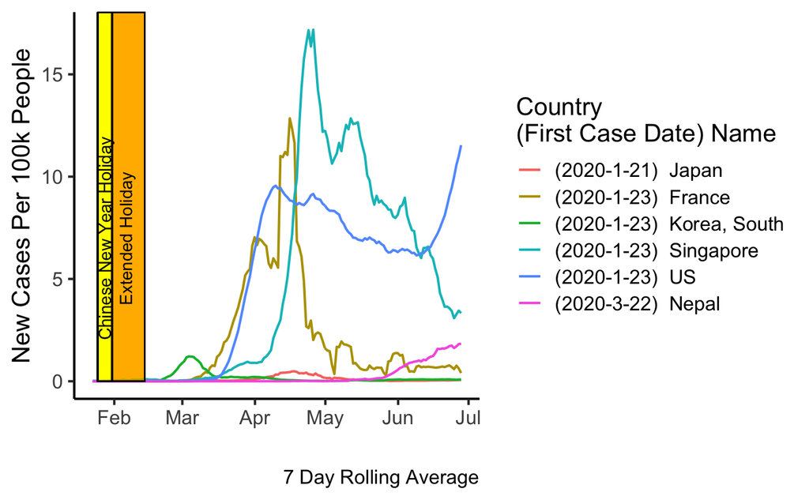

```r
p1 <- ggplot(before_data, aes(x=Date, y=new_confirmed100k, col=name_date_lab)) +
  geom_line(size=0.75) +
  theme_classic(base_size = 16) +
  labs(x="", y="New Cases Per 100k People", caption="7 Day Rolling Average", col="Country\n(First Case Date) Name") +
  geom_rect(
    fill = "yellow", alpha = 0.01,
    xmin = as.POSIXct(strptime("2020-01-25", "%Y-%m-%d")),
    xmax = as.POSIXct(strptime("2020-01-31", "%Y-%m-%d")),
    ymin = 0,
    ymax = Inf,
    col="black"
  ) +
  geom_rect(
    fill = "orange", alpha = 0.01,
    xmin = as.POSIXct(strptime("2020-01-31", "%Y-%m-%d")),
    xmax = as.POSIXct(strptime("2020-02-14", "%Y-%m-%d")),
    ymin = 0,
    ymax = Inf,
    col="black"
  ) +
  annotate(geom = "text", x = as.POSIXct(strptime("2020-01-28", "%Y-%m-%d")), y = 7, label = "Chinese New Year Holiday", color = "black",
             angle = 90) +
  annotate(geom = "text", x = as.POSIXct(strptime("2020-02-06", "%Y-%m-%d")), y = 7, label = "Extended Holiday", color = "black",
             angle = 90)

ggsave(p1, filename = "images/beforeCNY.png", width = 8)
p1
```

```r
cny_data$Country %>% unique()
```

```
 [1] "Australia"            "Cambodia"             "Canada"               "Finland"              "Germany"
 [6] "India"                "Italy"                "Philippines"          "Russia"               "Sri Lanka"
[11] "Sweden"               "United Arab Emirates" "United Kingdom"
```

Plot of countries with first cases during CNY. Colored by subregion

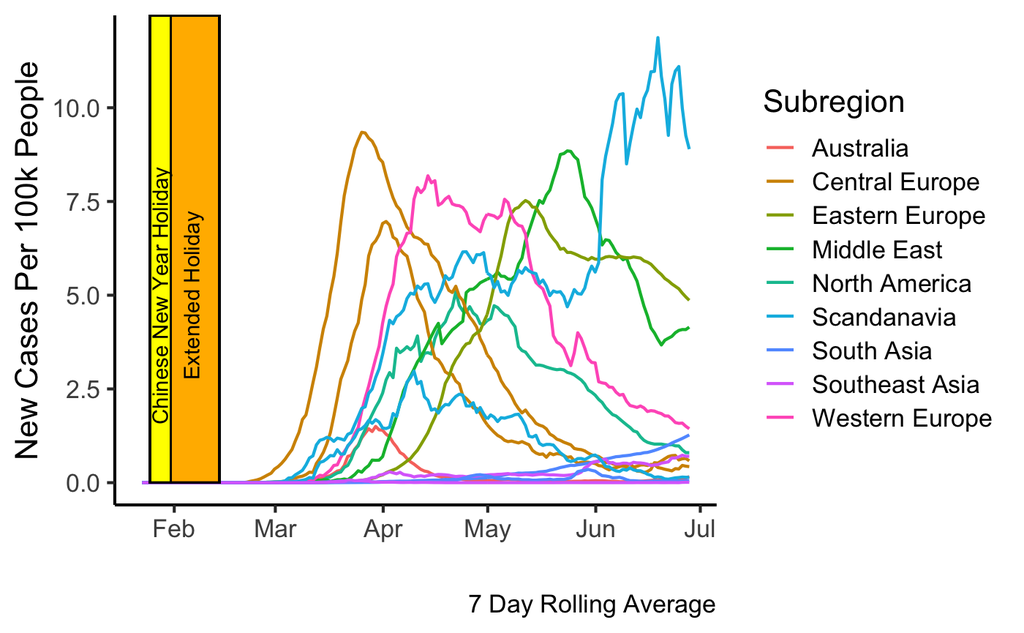

```r
ggplot(cny_data, aes(x=Date, y=new_confirmed100k, col=Subregion)) +
  geom_line(size=0.75, aes(group=name_date_lab)) +
  theme_classic(base_size = 16) +
  labs(x="", y="New Cases Per 100k People", caption="7 Day Rolling Average", col="Subregion") +
  geom_rect(
    fill = "yellow", alpha = 0.01,
    xmin = as.POSIXct(strptime("2020-01-25", "%Y-%m-%d")),
    xmax = as.POSIXct(strptime("2020-01-31", "%Y-%m-%d")),
    ymin = 0,
    ymax = Inf,
    col="black"
  ) +
  geom_rect(
    fill = "orange", alpha = 0.01,
    xmin = as.POSIXct(strptime("2020-01-31", "%Y-%m-%d")),
    xmax = as.POSIXct(strptime("2020-02-14", "%Y-%m-%d")),
    ymin = 0,
    ymax = Inf,
    col="black"
  ) +
  annotate(geom = "text", x = as.POSIXct(strptime("2020-01-28", "%Y-%m-%d")), y = 5, label = "Chinese New Year Holiday", color = "black",
             angle = 90) +
  annotate(geom = "text", x = as.POSIXct(strptime("2020-02-06", "%Y-%m-%d")), y = 5, label = "Extended Holiday", color = "black",
             angle = 90)
```

```r
cny_data_agg <- cny_data %>% group_by(Subregion, Date) %>% summarize(sum_cases = sum(new_confirmed100k))
cny_data_agg
```

| Subregion | Date | sum_cases |
| --- | --- | --- |
| Australia | 2020-01-22 19:00:00 | 0.000000e+00 |
| Australia | 2020-01-23 19:00:00 | 0.000000e+00 |
| Australia | 2020-01-24 19:00:00 | 0.000000e+00 |
| Australia | 2020-01-25 19:00:00 | 3.921587e-03 |
| Australia | 2020-01-26 19:00:00 | 3.921587e-03 |
| Australia | 2020-01-27 19:00:00 | 3.267989e-03 |
| Australia | 2020-01-28 19:00:00 | 3.361360e-03 |
| Australia | 2020-01-29 19:00:00 | 5.042040e-03 |
| Australia | 2020-01-30 19:00:00 | 5.042040e-03 |
| Australia | 2020-01-31 19:00:00 | 6.722720e-03 |

[output cut: 990 more lines]

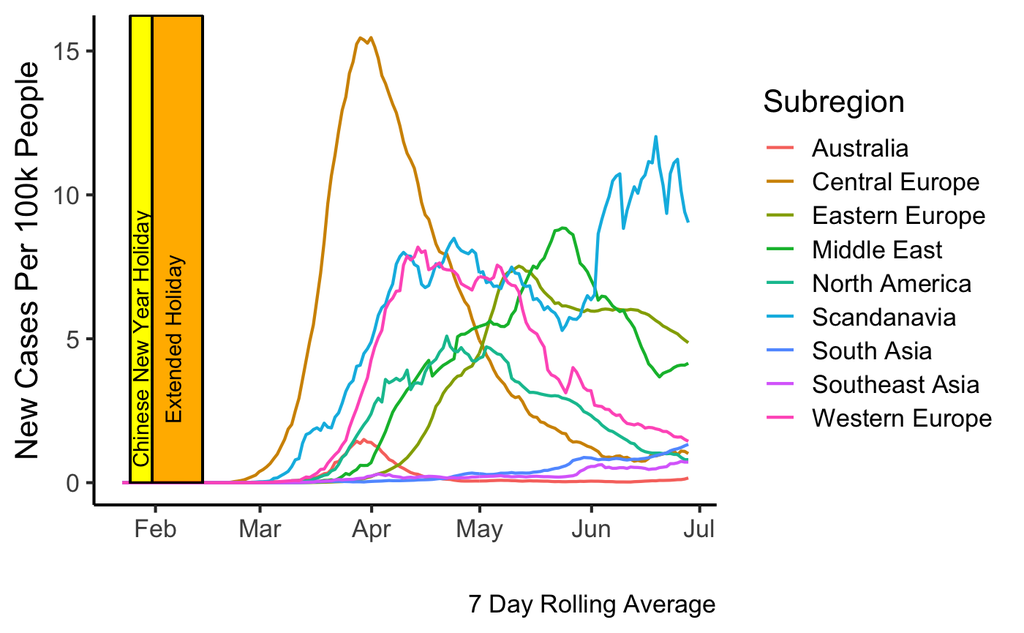

```r
p2 <- ggplot(cny_data_agg, aes(x=Date, y=sum_cases, col=Subregion)) +
  geom_line(size=0.75, aes(group=Subregion)) +
  theme_classic(base_size = 16) +
  labs(x="", y="New Cases Per 100k People", caption="7 Day Rolling Average", col="Subregion") +
  geom_rect(
    fill = "yellow", alpha = 0.01,
    xmin = as.POSIXct(strptime("2020-01-25", "%Y-%m-%d")),
    xmax = as.POSIXct(strptime("2020-01-31", "%Y-%m-%d")),
    ymin = 0,
    ymax = Inf,
    col="black"
  ) +
  geom_rect(
    fill = "orange", alpha = 0.01,
    xmin = as.POSIXct(strptime("2020-01-31", "%Y-%m-%d")),
    xmax = as.POSIXct(strptime("2020-02-14", "%Y-%m-%d")),
    ymin = 0,
    ymax = Inf,
    col="black"
  ) +
  annotate(geom = "text", x = as.POSIXct(strptime("2020-01-28", "%Y-%m-%d")), y = 5, label = "Chinese New Year Holiday", color = "black",
             angle = 90) +
  annotate(geom = "text", x = as.POSIXct(strptime("2020-02-06", "%Y-%m-%d")), y = 5, label = "Extended Holiday", color = "black",
             angle = 90)

ggsave(p2, filename="images/cny_subregion_countries_agg.png", width=8)
p2
```

Grouped by Subregion and Colored by Country

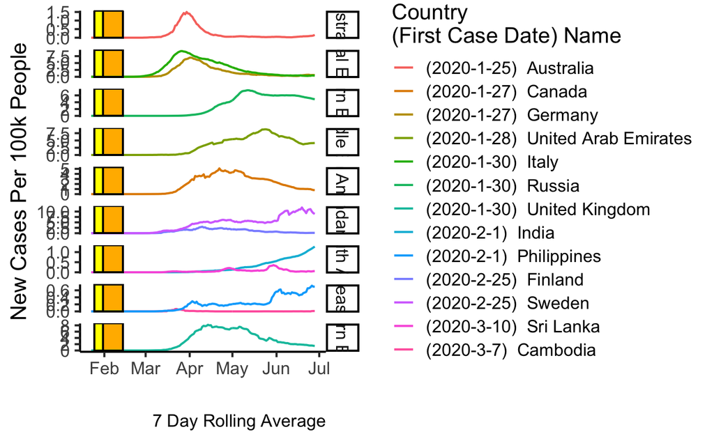

```r
p3 <- ggplot(cny_data, aes(x=Date, y=new_confirmed100k, col=name_date_lab)) +
  geom_line(size=0.75, aes(group=Country)) +
  facet_grid(vars(Subregion), scales="free") +
  theme_classic(base_size = 16) +
  labs(x="", y="New Cases Per 100k People", caption="7 Day Rolling Average", col="Country\n(First Case Date) Name") +
  geom_rect(
    fill = "yellow", alpha = 0.01,
    xmin = as.POSIXct(strptime("2020-01-25", "%Y-%m-%d")),
    xmax = as.POSIXct(strptime("2020-01-31", "%Y-%m-%d")),
    ymin = 0,
    ymax = Inf,
    col="black"
  ) +
  geom_rect(
    fill = "orange", alpha = 0.01,
    xmin = as.POSIXct(strptime("2020-01-31", "%Y-%m-%d")),
    xmax = as.POSIXct(strptime("2020-02-14", "%Y-%m-%d")),
    ymin = 0,
    ymax = Inf,
    col="black"
  )

ggsave(p3, filename = "images/cny_facet.png", height = 15, width = 8)

p3
```

```r
extended_data_agg <- extended_data %>% group_by(Subregion, Date) %>% summarize(sum_cases = sum(new_confirmed100k))
extended_data_agg
```

| Subregion | Date | sum_cases |
| --- | --- | --- |
| Australia | 2020-01-22 19:00:00 | 0.000000e+00 |
| Australia | 2020-01-23 19:00:00 | 0.000000e+00 |
| Australia | 2020-01-24 19:00:00 | 0.000000e+00 |
| Australia | 2020-01-25 19:00:00 | 3.921587e-03 |
| Australia | 2020-01-26 19:00:00 | 3.921587e-03 |
| Australia | 2020-01-27 19:00:00 | 3.267989e-03 |
| Australia | 2020-01-28 19:00:00 | 3.361360e-03 |
| Australia | 2020-01-29 19:00:00 | 5.042040e-03 |
| Australia | 2020-01-30 19:00:00 | 5.042040e-03 |
| Australia | 2020-01-31 19:00:00 | 6.722720e-03 |

[output cut: 990 more lines]

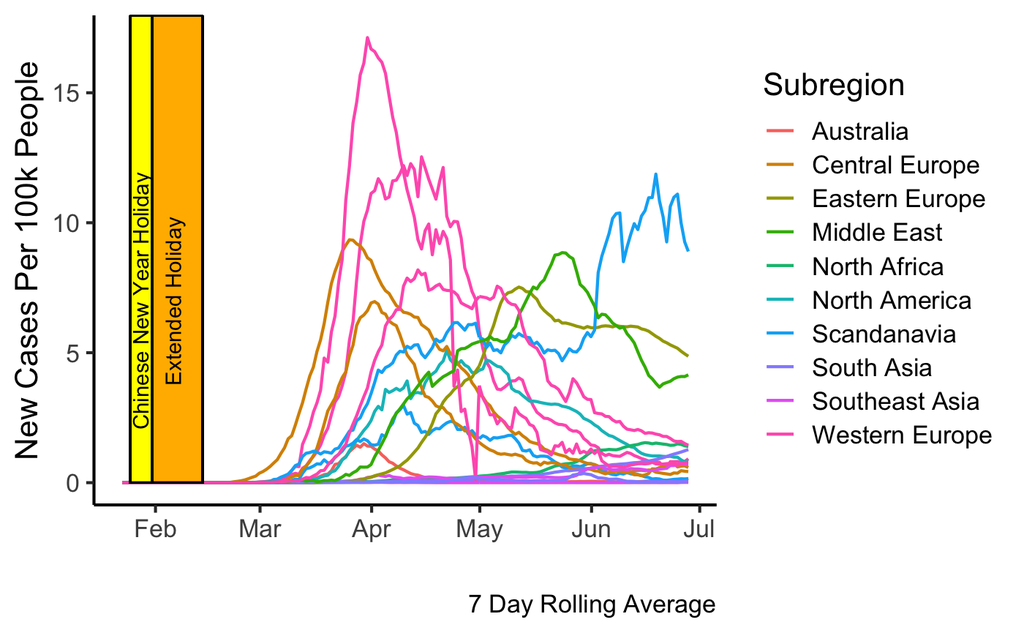

```r
ggplot(extended_data, aes(x=Date, y=new_confirmed100k, col=Subregion)) +
  geom_line(size=0.75, aes(group = Country)) +
  theme_classic(base_size = 16) +
  labs(x="", y="New Cases Per 100k People", caption="7 Day Rolling Average", col="Subregion") +
  geom_rect(
    fill = "yellow", alpha = 0.01,
    xmin = as.POSIXct(strptime("2020-01-25", "%Y-%m-%d")),
    xmax = as.POSIXct(strptime("2020-01-31", "%Y-%m-%d")),
    ymin = 0,
    ymax = Inf,
    col="black"
  ) +
  geom_rect(
    fill = "orange", alpha = 0.01,
    xmin = as.POSIXct(strptime("2020-01-31", "%Y-%m-%d")),
    xmax = as.POSIXct(strptime("2020-02-14", "%Y-%m-%d")),
    ymin = 0,
    ymax = Inf,
    col="black"
  ) +
  annotate(geom = "text", x = as.POSIXct(strptime("2020-01-28", "%Y-%m-%d")), y = 7, label = "Chinese New Year Holiday", color = "black",
             angle = 90) +
  annotate(geom = "text", x = as.POSIXct(strptime("2020-02-06", "%Y-%m-%d")), y = 7, label = "Extended Holiday", color = "black",
             angle = 90)
```

```r
# ggsave(p3, filename="images/extendedCNY_subregion.png", width=8)

# p3
```

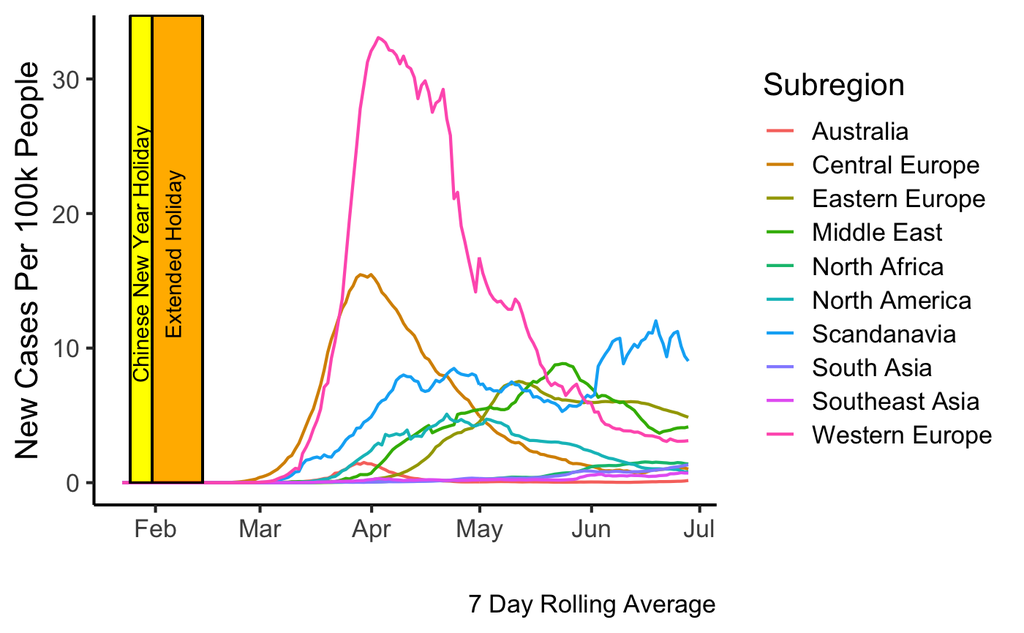

```r
p3 <- ggplot(extended_data_agg, aes(x=Date, y=sum_cases, col=Subregion)) +
  geom_line(size=0.75) +
  theme_classic(base_size = 16) +
  labs(x="", y="New Cases Per 100k People", caption="7 Day Rolling Average", col="Subregion") +
  geom_rect(
    fill = "yellow", alpha = 0.01,
    xmin = as.POSIXct(strptime("2020-01-25", "%Y-%m-%d")),
    xmax = as.POSIXct(strptime("2020-01-31", "%Y-%m-%d")),
    ymin = 0,
    ymax = Inf,
    col="black"
  ) +
  geom_rect(
    fill = "orange", alpha = 0.01,
    xmin = as.POSIXct(strptime("2020-01-31", "%Y-%m-%d")),
    xmax = as.POSIXct(strptime("2020-02-14", "%Y-%m-%d")),
    ymin = 0,
    ymax = Inf,
    col="black"
  ) +
  annotate(geom = "text", x = as.POSIXct(strptime("2020-01-28", "%Y-%m-%d")), y = 17, label = "Chinese New Year Holiday", color = "black",
             angle = 90) +
  annotate(geom = "text", x = as.POSIXct(strptime("2020-02-06", "%Y-%m-%d")), y = 17, label = "Extended Holiday", color = "black",
             angle = 90)

ggsave(p3, filename="images/extendedCNY_subregion.png", width=8)
p3
```

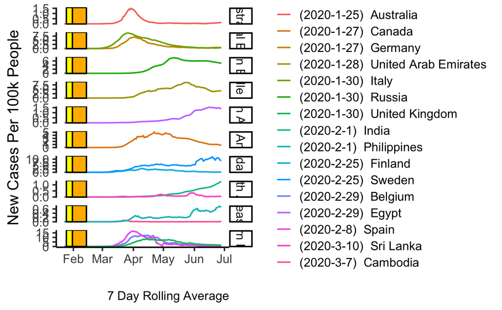

```r
p4 <- ggplot(extended_data, aes(x=Date, y=new_confirmed100k, col=name_date_lab)) +
  geom_line(size=0.75, aes(group = Country)) +
  theme_classic(base_size = 16) +
  facet_grid(vars(Subregion), scale='free') +
  labs(x="", y="New Cases Per 100k People", caption="7 Day Rolling Average", col="Country") +
  geom_rect(
    fill = "yellow", alpha = 0.01,
    xmin = as.POSIXct(strptime("2020-01-25", "%Y-%m-%d")),
    xmax = as.POSIXct(strptime("2020-01-31", "%Y-%m-%d")),
    ymin = 0,
    ymax = Inf,
    col="black"
  ) +
  geom_rect(
    fill = "orange", alpha = 0.01,
    xmin = as.POSIXct(strptime("2020-01-31", "%Y-%m-%d")),
    xmax = as.POSIXct(strptime("2020-02-14", "%Y-%m-%d")),
    ymin = 0,
    ymax = Inf,
    col="black"
  )

ggsave(p4, filename="images/extendedCNY_facet.png", height=15, width=8)

p4
```

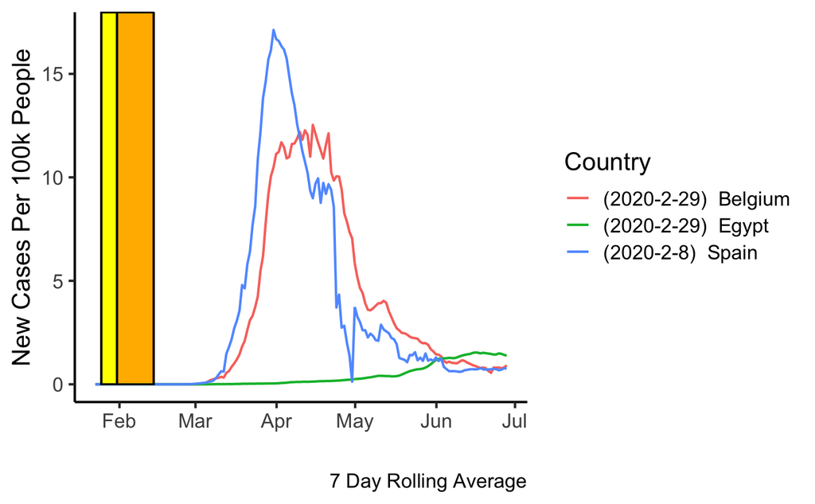

```r
p5 <- ggplot(onlyextended_data, aes(x=Date, y=new_confirmed100k, col=name_date_lab)) +
  geom_line(size=0.75) +
  theme_classic(base_size = 16) +
  labs(x="", y="New Cases Per 100k People", caption="7 Day Rolling Average", col="Country") +
  geom_rect(
    fill = "yellow", alpha = 0.01,
    xmin = as.POSIXct(strptime("2020-01-25", "%Y-%m-%d")),
    xmax = as.POSIXct(strptime("2020-01-31", "%Y-%m-%d")),
    ymin = 0,
    ymax = Inf,
    col="black"
  ) +
  geom_rect(
    fill = "orange", alpha = 0.01,
    xmin = as.POSIXct(strptime("2020-01-31", "%Y-%m-%d")),
    xmax = as.POSIXct(strptime("2020-02-14", "%Y-%m-%d")),
    ymin = 0,
    ymax = Inf,
    col="black"
  )

ggsave(p5, filename = "images/onlyextended_subregion.png", width = 8)
p5
```

```r
mil_c <- all_countries_agg %>% mutate(mil_cases = floor(Confirmed/1000000)) %>% group_by(mil_cases) %>% summarise(first_date = first(Date))
mil_c
```

| mil_cases | first_date |
| --- | --- |
| 0 | 2020-01-21 19:00:00 |
| 1 | 2020-04-01 20:00:00 |
| 2 | 2020-04-14 20:00:00 |
| 3 | 2020-04-26 20:00:00 |
| 4 | 2020-05-08 20:00:00 |
| 5 | 2020-05-20 20:00:00 |
| 6 | 2020-05-29 20:00:00 |
| 7 | 2020-06-07 20:00:00 |
| 8 | 2020-06-15 20:00:00 |
| 9 | 2020-06-21 20:00:00 |

[output cut: 1 more lines]

```r
time_diff <- mil_c$first_date %>% diff()
mil_c <- mil_c[-1,]
mil_c['lag'] <- time_diff
```